# DataAn3_SalgaB

## Introduction

This analysis aims to help a company’s new, currently not operating small and mid-size apartments price setting. In the first part, the dataset will be clean and I will create some variables to make the analysis clearer and easier. I have to check what kind of factors have effects on the price of an apartment. To do that, many different methods (OLS, LASSO, Random forest) will be raced to see which performs better and its results have a better fit on the dataset. For the sake of the analysis, the Airbnb dataset was used that includes information on many thousands of apartments in and around Sydney. In this analysis, I build a price prediction model to help the company.

## Data cleaning

The data had been downloaded free from http://insideairbnb.com/get-the-data.html. Only the Sydney dataset was downloaded and used. After the data has been loaded, I checked where are NA values were in the dataset. Sixteen variables had NA values. If in a column was less than 10 NA values, I removed them: neighborhood_overview, host_listings_count, host_total_listings_count. I also removed those variables that had nothing to do with the current analysis (different names and URLs). Other NA values in different variables were replaced with their mean values since these are probably missing values and not 0. So, for the analysis, I changed them to their mean values. Some variables only had NA values. I removed those entirely as well. In the second part, I started to create variables for the analysis. I created the number of days since the apartment is on the market, and also I created its logarithm and square form, to be able to analyze the effect of time. I also made the logarithm form of price and number of reviews for early data analysis. I also created some dummy variables from different with the ‘fastDummies’ package, since those variables only had True and False values. I applied filters to set apartments and apartment type houses, and also I filtered put those variables, which price was more than 1000 dollars.

## Analysis

Before the analysis, I checked the price of the apartments variables (also viewed its logarithm form) for extreme values with a histogram graph I did not find many, which is better for the analysis. I also checked the price of each room type. The boxplot results show the price range of each room type. The boxplot graph shows, what can I expect for the resulting price at the end of each part of the analysis. The “entire home/apartments” are around 310 US dollars, but those apartments, which are in the private room type are around 750 US dollars.

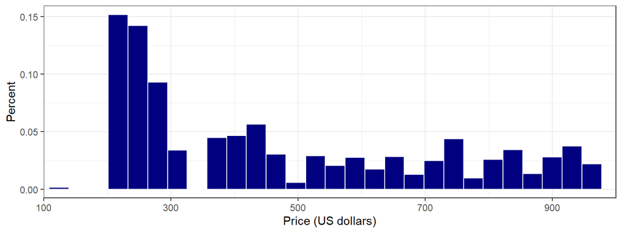

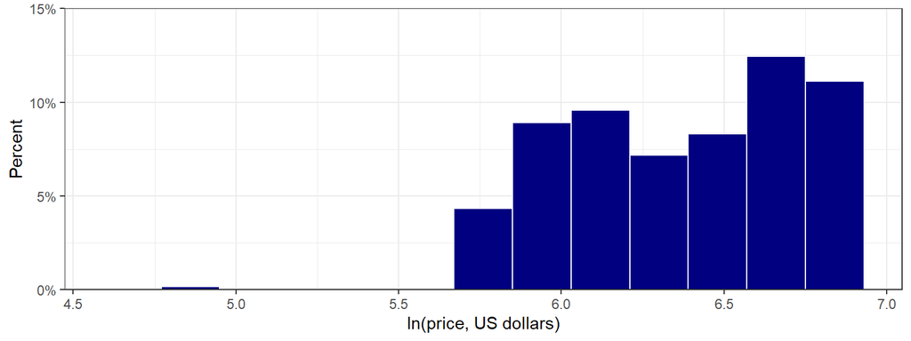

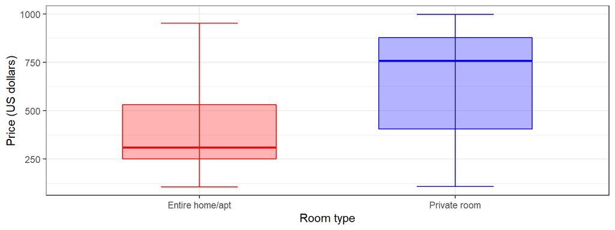

The training dataset I created has 8695 observations, which is better for the model estimation, and the holdout dataset with 3724 observations is still well enough for performance evaluation. For the analysis, I created 3 predictors: The first one has only the basic variables, which contain only variables, which can have a major effect on apartment prices. The second predictor contains the basic variables, along with the variables about reviews, and the dummy variables I created as extra. The last predictor has extra observations for the LASSO model. For the first part of my analysis, I started with random forests. To tune all the models, I used five-fold cross-validation everywhere, and eight variables at the random forest for each split. I used the ‘variance’ method, for optimizing the Mean Squared Error.

```
##    user  system elapsed
##   51.33    0.53    9.78
```

```
##    user  system elapsed
##   76.46    0.55   13.52
```

```
##
## Call:
## summary.resamples(object = results)
##
## Models: model_1, model_2
## Number of resamples: 5
##
## MAE
##             Min.  1st Qu.   Median     Mean  3rd Qu.     Max. NA's
## model_1 171.0412 171.7351 172.7103 173.0939 173.1577 176.8251    0
## model_2 167.0629 168.6773 169.5697 169.6218 169.9315 172.8675    0
##
## RMSE
##             Min.  1st Qu.   Median     Mean  3rd Qu.     Max. NA's
## model_1 209.8892 210.6108 213.4731 212.5989 213.6775 215.3440    0
## model_2 207.2511 207.4891 210.9763 209.8692 211.5123 212.1173    0
##
## Rsquared
##              Min.   1st Qu.    Median      Mean   3rd Qu.      Max. NA's
## model_1 0.2791568 0.2852194 0.2948065 0.2972913 0.3119959 0.3152775    0
## model_2 0.2887277 0.3018625 0.3132426 0.3126546 0.3282471 0.3311929    0
```

After the foundation of the better model for the dataset, I started to check the variable importance. I plotted them with the help of the ranger package. To improve the Mean Squared Error I scaled back model_2 by 1000. The results show that the first 4 most influential variables on price are related to Room type: Private (almost 20%) and Property type: Entire, Private rental units (6% - 17%). The rest of the TOP 10 most influential variables were 2.5% and 4%. For the sake of the analysis, I considered that there is no causal link between the Top 10 most influential variables and the price of the apartments. This graph showed the direction, where should I start my investigation.

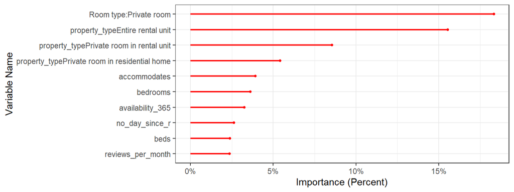

After the grouping is applied to the variables, the graph shows a much clearer picture of the importance. Property Type has the highest calculated importance (almost 45%). Room type and Neighbourhood have much less important in terms of price (25% and 15%). The interesting part for me is that the number of accommodates has only around 5%. Before the analysis, my prediction was that the variable accommodates will have very high importance.

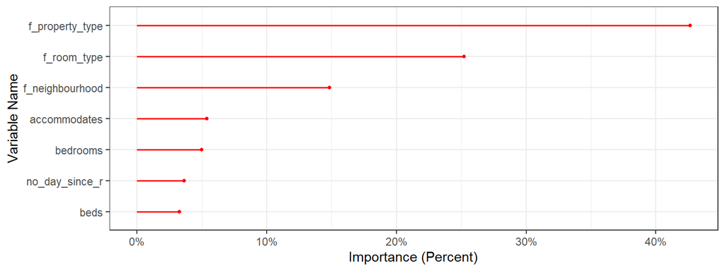

At this part of the analysis, I wanted to predict the price of apartments at different variables and visualize them. I used only the second random forest model since it was more sophisticated. The prediction of these models is based on the data_train sample, however, the expected values are coming from the data_holdout sample. In the first graph, I predicted the price of apartments in different neighborhoods. The results show that in most cases the prices are not so volatile. The predicted prices for most cases move between 475 and 495 US dollars. The second graph shows the predicted price for different room types. By the room types, the predicted prices are much more volatile. The Private rooms (530 US dollars) are 80 US dollars more expensive than the Entire homes and apartments. The last graph shows the predicted prices of apartments by the number of accommodates. The accommodates variable again shows interesting results: The predicted values for 3 and 4 people are the cheapest, an apartment for two people is more expensive than a one with a place for five people. Maybe this trend is because apartments for two people are aiming to be more luxurious.

```
## geom_path: Each group consists of only one observation. Do you need to adjust
## the group aesthetic?
```

[figure not shown]

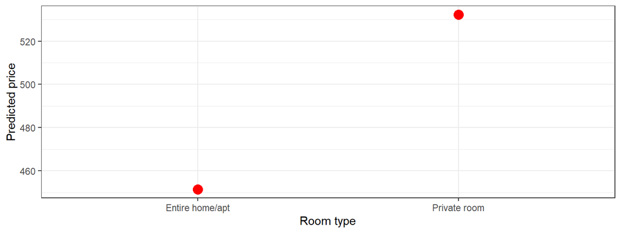

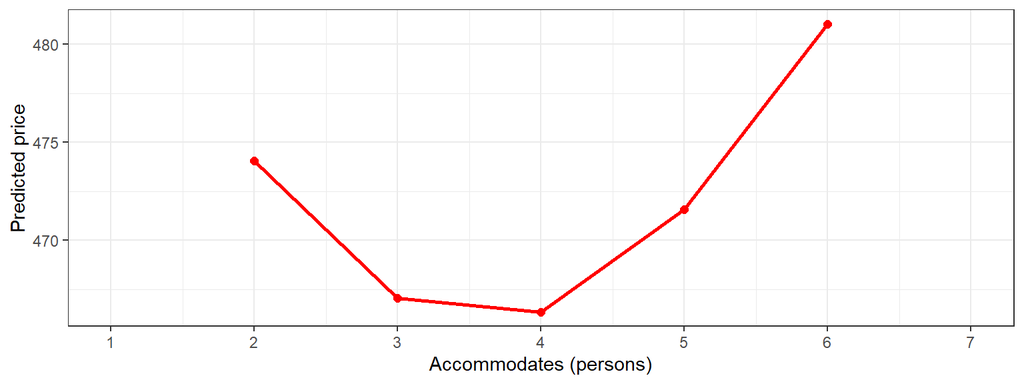

```
##              Var.1     RMSE Mean.price RMSE.price
## 1   Apartment size       NA         NA         NA
## 2        large apt 182.5280   452.0926  0.4037403
## 3        small apt 230.1747   498.4272  0.4618020
## 4             Type       NA         NA         NA
## 5  Entire home/apt 185.9551   409.1640  0.4544758
## 6     Private room 263.8439   650.4420  0.4056379
## 7         District       NA         NA         NA
## 8           Auburn 177.6492   494.4717  0.3592708
## 9     Campbelltown 260.7803   623.3636  0.4183438
## 10 City Of Kogarah 172.4841   535.6818  0.3219899
## 11         Hornsby 208.8842   491.0426  0.4253892
## 12    North Sydney 177.3000   394.3179  0.4496372
## 13        Randwick 226.7637   506.2703  0.4479103
## 14          Sydney 207.6007   442.7341  0.4689061
## 15        Waverley 204.7022   459.6601  0.4453339
## 16       Woollahra 212.3092   472.9935  0.4488629
## 17             All 211.4507   478.9428  0.4414947
```

The last part of this analysis compares different prediction methods to see, which method gives the best possible results. It is important to check many methods since a company will set the prices of its apartments. The company’s profit is hugely affected by this analysis and prediction. To not make any mistakes, I checked many methods to find the best solution. The first model is an OLS and the second predictor model was used for the calculation. The second model is the LASSO model, which used the third predictor model with the interactions. The last method is CART, where again the second model was used. The difference at the last method: the model is tuned for 10 complexity parameters to chose from, using only cross-validation. A boosting model was also used for better results. The GBM model was tuned for 250 pieces of 5 layers deep tree building, shrinkage is 0.1 and the minimum number of observations is 20.

As the result of the current analysis, I think the company, which rents apartments on Airbnb, should focus GBM model with extended variables. My decision is based on, GBMt model has the highest performance in predictions. In the future, they can use this model easier, faster, and more accurately compared to other models to check their prices. The GBM and the second Random Forest performed equally well. These models are followed by CART and then LASSO model. The last contender is OLS. The best model, estimate it on the work set, and evaluate it on the holdout set. The best model is GBM and its holdout set RMSE is 210.2. The expectation is to make an error of 210 US dollars when using the model on the live data. The holdout set RMSE is quite close to the cross-validated RMSE. So, the company should consider the RMSE, when they set their models to predict their apartments prices. The RMSE is quite huge and the R2 is also not so good. The analysis could be better, if I could generate binary variables from the amenities variable.

```
##    user  system elapsed
##    4.91    0.08    4.98
```

```
##    user  system elapsed
##  123.16    9.31  132.98
```

```
##    user  system elapsed
##   11.05    0.04   11.12
```

```
##    user  system elapsed
##  112.56    0.11  113.05
```

```
##
## Call:
## summary.resamples(object = .)
##
## Models: OLS, LASSO (model w/ interactions), CART, Random forest 1: smaller model, Random forest 2: extended model, GBM
## Number of resamples: 5
##
## MAE
##                                     Min.  1st Qu.   Median     Mean  3rd Qu.
## OLS                             166.1915 166.9871 170.2083 169.2428 170.9208
## LASSO (model w/ interactions)   162.7583 163.4181 164.7373 164.5370 165.6541
## CART                            163.4170 164.4659 166.8899 166.4835 167.3191
## Random forest 1: smaller model  171.0412 171.7351 172.7103 173.0939 173.1577
## Random forest 2: extended model 167.0629 168.6773 169.5697 169.6218 169.9315
## GBM                             157.6919 159.1391 160.4797 160.6381 161.9188
##                                     Max. NA's
## OLS                             171.9066    0
## LASSO (model w/ interactions)   166.1171    0
## CART                            170.3256    0
## Random forest 1: smaller model  176.8251    0
## Random forest 2: extended model 172.8675    0
## GBM                             163.9612    0
##
## RMSE
##                                     Min.  1st Qu.   Median     Mean  3rd Qu.
## OLS                             212.1685 213.3278 217.2893 216.1087 218.0681
## LASSO (model w/ interactions)   211.8669 212.2115 212.5170 213.3559 213.7209
## CART                            208.4726 210.0755 213.6446 212.1992 213.9854
## Random forest 1: smaller model  209.8892 210.6108 213.4731 212.5989 213.6775
## Random forest 2: extended model 207.2511 207.4891 210.9763 209.8692 211.5123
## GBM                             205.1174 207.3185 208.9714 208.5171 209.4936
##                                     Max. NA's
## OLS                             219.6896    0
## LASSO (model w/ interactions)   216.4633    0
## CART                            214.8183    0
## Random forest 1: smaller model  215.3440    0
## Random forest 2: extended model 212.1173    0
## GBM                             211.6845    0
##
## Rsquared
##                                      Min.   1st Qu.    Median      Mean
## OLS                             0.2275151 0.2438594 0.2634603 0.2559834
## LASSO (model w/ interactions)   0.2527970 0.2737499 0.2754055 0.2759977
## CART                            0.2594760 0.2733476 0.2857989 0.2821752
## Random forest 1: smaller model  0.2791568 0.2852194 0.2948065 0.2972913
## Random forest 2: extended model 0.2887277 0.3018625 0.3132426 0.3126546
## GBM                             0.2810921 0.3049655 0.3121587 0.3069101
##                                   3rd Qu.      Max. NA's
## OLS                             0.2715811 0.2735010    0
## LASSO (model w/ interactions)   0.2825529 0.2954829    0
## CART                            0.2935957 0.2986578    0
## Random forest 1: smaller model  0.3119959 0.3152775    0
## Random forest 2: extended model 0.3282471 0.3311929    0
## GBM                             0.3153621 0.3209722    0
```

```
##                                  CV RMSE
## OLS                             216.1087
## LASSO (model w/ interactions)   213.3559
## CART                            212.1992
## Random forest 1: smaller model  212.5989
## Random forest 2: extended model 209.8692
## GBM                             208.5171
```

```
##                                 Holdout RMSE
## OLS                                 220.1260
## LASSO (model w/ interactions)       215.5275
## CART                                215.7493
## Random forest 1: smaller model      214.0365
## Random forest 2: extended model     211.4507
## GBM                                 210.2321
```